# viz

REFG

2023-03-20

```r
cps <- read_csv("cpswmiss.csv")[,-1]
```

```
## ──────────────────────────────────────────────────────── Delimiter: "," dbl
## (27): ...1, NSCAWID, chdGendr, chdAgeY, CGDPOVRT, chRrace, ch2AgeY, TC2_...
```

```r
cps <- cps %>% filter(chdAgeY <= 5)

cps <- rename(cps,
                            asthma=HS33a1a,
                            adhd = HS33a2a,
                            asd = HS33a3a,
                            downsyn = HS33a4a,
                            mr = HS33a5a,
                            anxdep = HS33a6a,
                            diabetes = HS33a7a,
                            insulin = HS33a8a,
                            heartprob = HS33a9a,
                            bloodprob = HS33a10a,
                            cysticfib = HS33a11a,
                            cp = HS33a12a,
                            muscdyst = HS33a13a,
                            epilepsy = HS33a14a,
                            hypertension = HS33a25a,
                            healthprob = HS33a31a,
                            weight = HS31h42,
                            Poverty = CGDPOVRT,
                            Internalizing = TC2_IPT ,
                            Externalizing = TC2_EPT,
                            Ethnicity = chRrace,
                            Gender = chdGendr)

cps[cps <0] <- NA

cps <- cps %>% mutate(
    Poverty = case_when(Poverty <=2 ~ 1,
                        Poverty >=3 ~ 0)
)



cps <- cps  %>%  mutate_at(vars(10:26),
          ~as.factor(recode(.,
                             "1"=1,
                             "2"=0,
                                             "3" = 0)))


cps$Gender <- as.factor(cps$Gender)
cps$Poverty<- as.factor(cps$Poverty)
cps$Ethnicity<- as.factor(cps$Ethnicity)


describe(cps)
```

```
## cps
##
##  26  Variables      3019  Observations
## --------------------------------------------------------------------------------
## NSCAWID
##        n  missing distinct     Info     Mean      Gmd      .05      .10
##     3019        0     3019        1   208963     1967   206274   206560
##      .25      .50      .75      .90      .95
##   207496   208985   210450   211285   211581
##
## lowest : 206002 206003 206004 206005 206007, highest: 211863 211868 211870 211871 211873
## --------------------------------------------------------------------------------
## Gender
##        n  missing distinct
##     3019        0        2
##
## Value          1     2
## Frequency   1602  1417
## Proportion 0.531 0.469
## --------------------------------------------------------------------------------
## chdAgeY
##        n  missing distinct     Info     Mean      Gmd
##     3019        0        6    0.882    1.294    1.674
##
## lowest : 0 1 2 3 4, highest: 1 2 3 4 5
##
## Value          0     1     2     3     4     5
## Frequency   1430   636   255   246   237   215
## Proportion 0.474 0.211 0.084 0.081 0.079 0.071
## --------------------------------------------------------------------------------
## Poverty
##        n  missing distinct
##     2731      288        2
##
## Value          0     1
## Frequency   1278  1453
## Proportion 0.468 0.532
## --------------------------------------------------------------------------------
## Ethnicity
##        n  missing distinct
```

[output cut: 163 more lines]

```
##        n  missing distinct
##      484     2535        2
##
## Value          0     1
## Frequency    439    45
## Proportion 0.907 0.093
## --------------------------------------------------------------------------------
## weight
##        n  missing distinct
##      483     2536        2
##
## Value          0     1
## Frequency    464    19
## Proportion 0.961 0.039
## --------------------------------------------------------------------------------
```

```r
tabyl(cps$Ethnicity)
```

```
##  cps$Ethnicity    n    percent valid_percent
##              1  216 0.07154687    0.07374531
##              2 1108 0.36700894    0.37828610
##              3 1518 0.50281550    0.51826562
##              4   87 0.02881749    0.02970297
##           <NA>   90 0.02981120            NA
```

```r
#write.csv(cps, file= "cps.csv")
```

```r
povlabs <- c("Below Poverty", "Above Poverty")
testxpov <- cps %>% pivot_longer(
    cols = 7:8,
    names_to = "test",
    values_to = "score") %>% filter(!is.na(score)) %>%
    ggplot(aes(score, as.factor(Poverty), group=Poverty)) +
                    geom_jitter(aes(color=test))+
                    geom_boxplot(alpha = .8) +
    scale_y_discrete(labels= povlabs) +
    scale_color_okabe_ito() +
    labs(title = "Test Scores by Poverty Status",
             x = "Test Score",
             y = "Poverty status",
             color = "Test",
             caption = "Youth Behavior Checklist - Wave 2")

#Section TC:

save_plot(testxpov, file ="testxpov.png")
```

```r
povlabs
```

```
## [1] "Below Poverty" "Above Poverty"
```

```r
outcome <- cps %>%
    pivot_longer(
        cols = c(10:12,15,26),
        names_to = "health_stat",
        values_to = "health_score"
    ) %>% pivot_longer(
    cols = 7:8,
    names_to = "test",
    values_to = "score") %>% filter(!is.na(score)) %>%
    mutate(health_yn = case_when(health_score == 1 ~ "yes",
                                     health_score == 2 ~ as.character(NA),
                                     health_score == 3 ~ as.character(NA)
    )) %>% filter(!is.na(health_yn))%>%
    ggplot(aes(score,health_stat))+
    geom_jitter(aes(color=Gender), alpha = .7) +
    geom_boxplot(aes(fill = test)) +
    scale_color_manual(labels = c("Male", "Female"), values = c("darkorchid", "darkseagreen2"))+
    scale_fill_okabe_ito(alpha = .5) +
    labs(x = "",
             y = "",
             title = "Chronic health outcome and test score by biological sex",
             color = "Biological sex",
             fill = "") +
    facet_wrap(~test)

save_plot(outcome, file = "outcome.png")
```

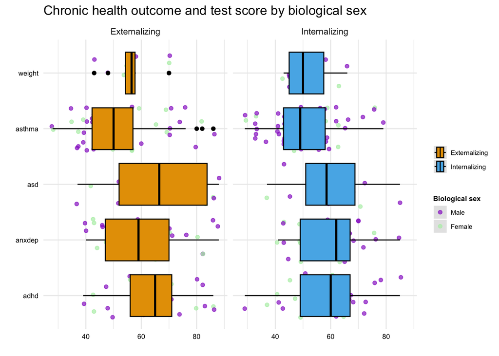

```r
outcome
```

```r
rcorr(as.matrix(cps, na.rm=T))
```

```
##               NSCAWID Gender chdAgeY Poverty Ethnicity ch2AgeY Externalizing
## NSCAWID          1.00   0.00    0.03    0.01     -0.02    0.01         -0.11
## Gender           0.00   1.00   -0.02   -0.01     -0.05   -0.02         -0.10
## chdAgeY          0.03  -0.02    1.00    0.06      0.06    0.97          0.10
## Poverty          0.01  -0.01    0.06    1.00     -0.08    0.06          0.05
## Ethnicity       -0.02  -0.05    0.06   -0.08      1.00    0.08          0.07
## ch2AgeY          0.01  -0.02    0.97    0.06      0.08    1.00          0.14
## Externalizing   -0.11  -0.10    0.10    0.05      0.07    0.14          1.00
## Internalizing   -0.07  -0.08    0.19    0.10      0.05    0.24          0.71
## ch3AgeY          0.00   0.00    0.97    0.09      0.06    0.96          0.06
## asthma           0.06  -0.08   -0.04   -0.10      0.02   -0.02         -0.01
## adhd            -0.02  -0.04    0.27   -0.05     -0.05    0.30          0.35
## asd             -0.06  -0.08   -0.01    0.03     -0.02   -0.03          0.25
## downsyn          0.02   0.00   -0.04    0.03      0.05   -0.03         -0.04
## mr              -0.02  -0.06   -0.03   -0.01      0.04   -0.04          0.17
## anxdep          -0.03  -0.02    0.19    0.04      0.04    0.18          0.24
## diabetes         0.07   0.00    0.08    0.03      0.00    0.09         -0.04
## insulin          1.00   1.00    1.00   -1.00      1.00    1.00            NA
## heartprob       -0.02  -0.09   -0.02   -0.03      0.04    0.02          0.13
## bloodprob       -0.07  -0.06    0.01    0.00      0.02    0.00          0.07
## cysticfib       -0.05  -0.06    0.01    0.07      0.00    0.01          0.18
## cp              -0.02  -0.04   -0.05    0.02     -0.03   -0.05          0.04
## muscdyst        -0.01  -0.04   -0.02     NaN      0.03   -0.03          0.09
## epilepsy        -0.01   0.00   -0.06    0.02      0.03   -0.07          0.05
## hypertension     0.02   0.00    0.01   -0.04      0.05    0.01          0.09
## healthprob       0.03  -0.04   -0.04   -0.09      0.02   -0.03          0.06
## weight          -0.10   0.03    0.01    0.01     -0.04   -0.02          0.08
##               Internalizing ch3AgeY asthma  adhd   asd downsyn    mr anxdep
## NSCAWID               -0.07    0.00   0.06 -0.02 -0.06    0.02 -0.02  -0.03
## Gender                -0.08    0.00  -0.08 -0.04 -0.08    0.00 -0.06  -0.02
## chdAgeY                0.19    0.97  -0.04  0.27 -0.01   -0.04 -0.03   0.19
## Poverty                0.10    0.09  -0.10 -0.05  0.03    0.03 -0.01   0.04
## Ethnicity              0.05    0.06   0.02 -0.05 -0.02    0.05  0.04   0.04
## ch2AgeY                0.24    0.96  -0.02  0.30 -0.03   -0.03 -0.04   0.18
## Externalizing          0.71    0.06  -0.01  0.35  0.25   -0.04  0.17   0.24
## Internalizing          1.00    0.14   0.05  0.27  0.19    0.05  0.23   0.30
## ch3AgeY                0.14    1.00  -0.04  0.27  0.01   -0.03 -0.02   0.19
## asthma                 0.05   -0.04   1.00  0.05 -0.06    0.05  0.02   0.02
## adhd                   0.27    0.27   0.05  1.00  0.24   -0.02  0.15   0.28
## asd                    0.19    0.01  -0.06  0.24  1.00   -0.01  0.35   0.08
```

[output cut: 273 more lines]

```
## asd           0.1612   0.0033       0.0070     0.9590
## downsyn       0.0003   0.9275       0.0471     0.7748
## mr            0.0000   0.0848       0.0030     0.9018
## anxdep        0.0711   0.0000       0.0063     0.9898
## diabetes      0.7876   0.9275       0.6508     0.7748
## insulin
## heartprob     0.0000   0.8219       0.0580     0.4283
## bloodprob     0.1637   0.8548       0.1235     0.5648
## cysticfib     0.0000   0.9275       0.0000     0.7748
## cp            0.0000   0.8219       0.0000     0.4788
## muscdyst      0.0000   0.9488       0.0017     0.8399
## epilepsy               0.7876       0.0002     0.3967
## hypertension  0.7876                0.0471     0.7748
## healthprob    0.0002   0.0471                  0.5345
## weight        0.3967   0.7748       0.5345
```

```r
corr <- plot_corr(
  cps,
  vrb = c("Externalizing", "Internalizing", "adhd", "weight", "anxdep", "asthma", "asd", "Poverty", "Gender"),
  label = TRUE,
  square = FALSE,
  diagonal = TRUE,
  rotate = TRUE
)

save_plot(corr, file="corr.jpg")
```

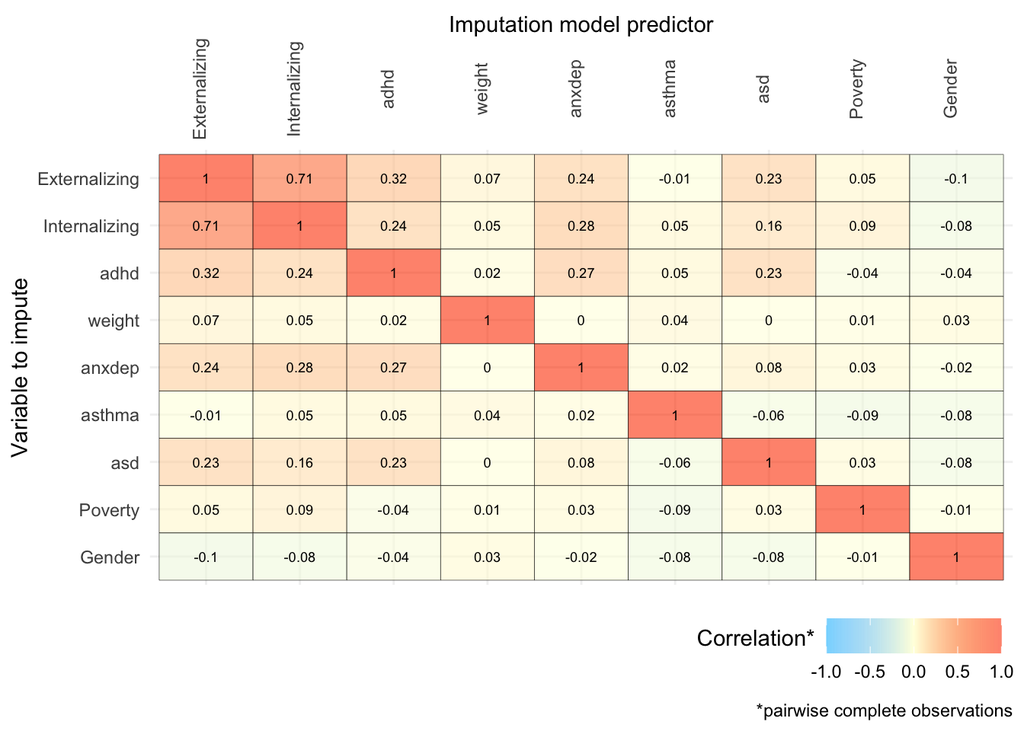

```r
corr
```

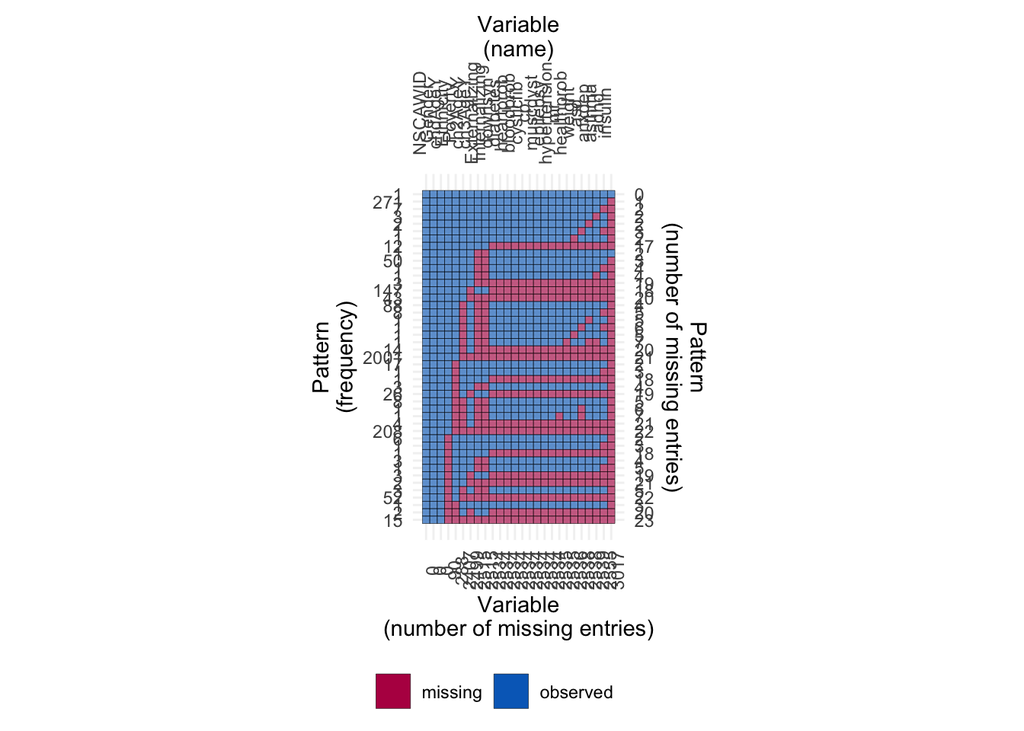

```r
plot_pattern(cps,square = TRUE, rotate = TRUE)
```

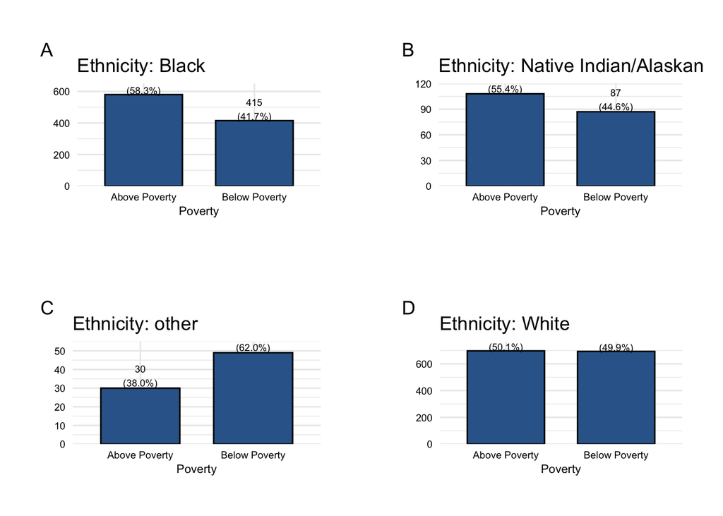

```r
demo2 <- cps %>%
    mutate(Ethnicity = case_when(Ethnicity == 1 ~ "Native Indian/Alaskan",
                                     Ethnicity == 2 ~ "Black",
                                     Ethnicity == 3 ~ "White",
                                     Ethnicity == 4 ~ "other"
    ),
    Poverty= case_when(Poverty == 0 ~ "Below Poverty",
                                             Poverty == 1 ~ "Above Poverty")) %>%
  group_by(Ethnicity) %>%
  plot_frq(Poverty) %>%
    plot_grid()
```

```r
save_plot( demo2, file="demo2.png")
```

```r
demo2
```

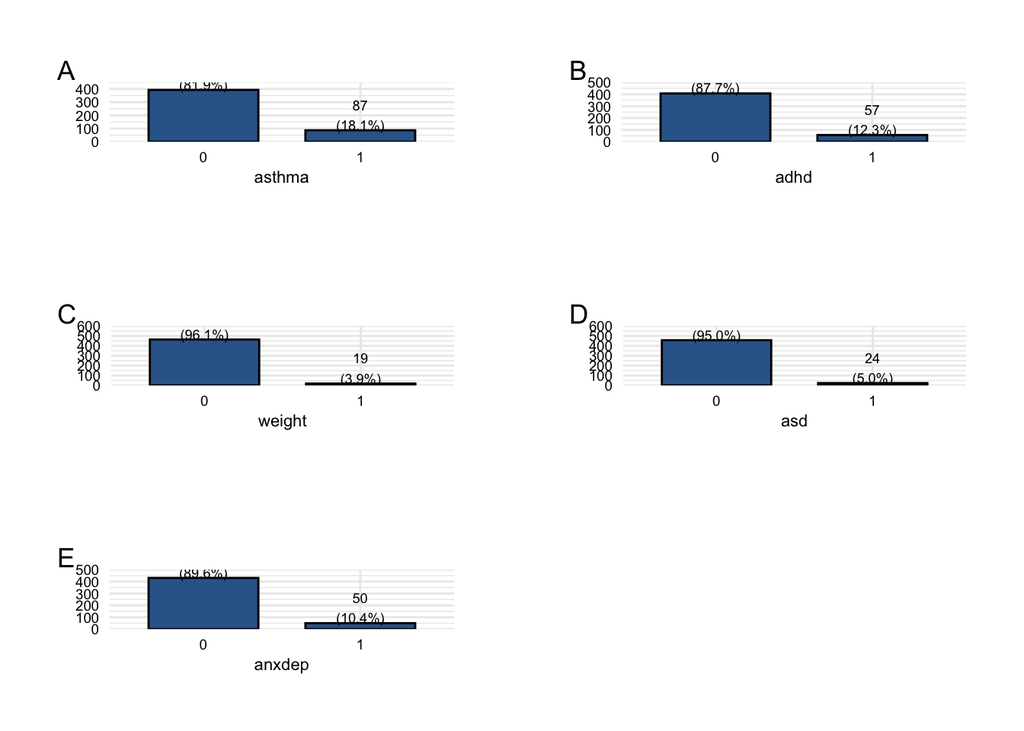

```r
cps %>%
  plot_frq(asthma, adhd, weight, asd, anxdep) %>%
    plot_grid()
```

```r
fit1 <- lm(asthma ~ Poverty + Internalizing  + Externalizing + Ethnicity+ Gender, data = cps)
fit2 <- lm(adhd ~ Poverty + Internalizing  + Externalizing + Ethnicity+ Gender, data = cps)
fit3 <- lm(asd ~ Poverty + Internalizing  + Externalizing + Ethnicity+ Gender, data = cps)
fit4 <- lm(weight ~ Poverty + Internalizing  + Externalizing + Ethnicity+ Gender, data = cps)
fit5 <- lm(anxdep ~ Poverty + Internalizing  + Externalizing + Ethnicity+ Gender, data = cps)
```

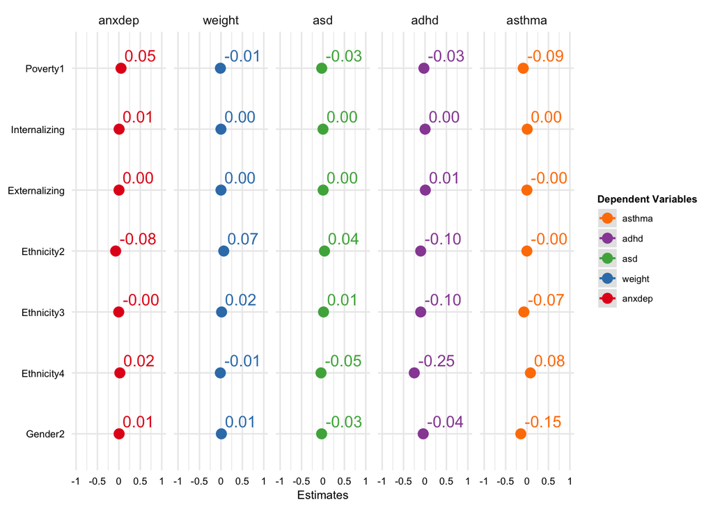

```r
# plot multiple models
plot_models(fit1, fit2, fit3, fit4, fit5, show.values = T, grid = TRUE)
```

```r
tab_model(fit1, fit2, fit3, fit4, fit5,
          collapse.ci = TRUE,
          p.style     = "numeric_stars")
```

asthma

adhd

asd

weight

anxdep

Predictors

Estimates

p

Estimates

p

Estimates

p

Estimates

p

Estimates

p

(Intercept)

1.27  
(NA – NA)

0.68  
(NA – NA)

0.81  
(NA – NA)

0.94  
(NA – NA)

0.70  
(NA – NA)

Poverty [1]

-0.09  
(NA – NA)

-0.03  
(NA – NA)

-0.03  
(NA – NA)

-0.01  
(NA – NA)

0.05  
(NA – NA)

Internalizing

0.00  
(NA – NA)

0.00  
(NA – NA)

0.00  
(NA – NA)

0.00  
(NA – NA)

0.01  
(NA – NA)

Externalizing

-0.00  
(NA – NA)

0.01  
(NA – NA)

0.00  
(NA – NA)

0.00  
(NA – NA)

0.00  
(NA – NA)

Ethnicity [2]

-0.00  
(NA – NA)

-0.10  
(NA – NA)

0.04  
(NA – NA)

0.07  
(NA – NA)

-0.08  
(NA – NA)

Ethnicity [3]

-0.07  
(NA – NA)

-0.10  
(NA – NA)

0.01  
(NA – NA)

0.02  
(NA – NA)

-0.00  
(NA – NA)

Ethnicity [4]

0.08  
(NA – NA)

-0.25  
(NA – NA)

-0.05  
(NA – NA)

-0.01  
(NA – NA)

0.02  
(NA – NA)

Gender [2]

-0.15  
(NA – NA)

-0.04  
(NA – NA)

-0.03  
(NA – NA)

0.01  
(NA – NA)

0.01  
(NA – NA)

Observations

283

278

285

285

284

- p<0.05 ** p<0.01 *** p<0.001